# Biomass Dynamic Assessment Model

Laurence Kell

06 marzo, 2018

## Simulate CPUE and Indices of abundance

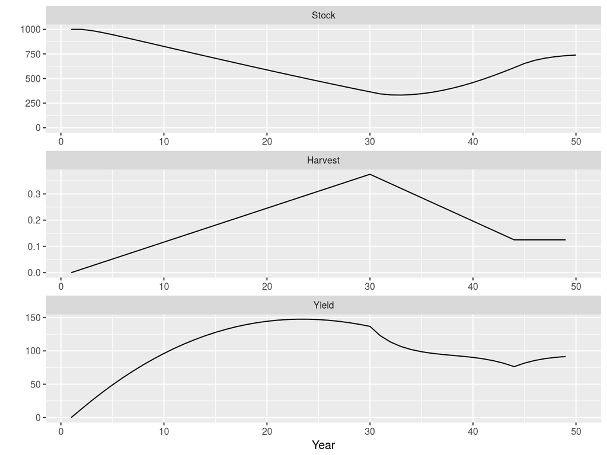

**Figure 1** Simulated stock trends

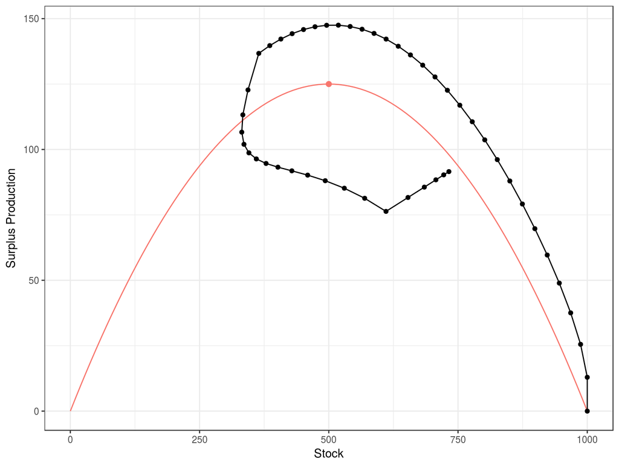

**Figure 2** Simulated production function with stock trajectory

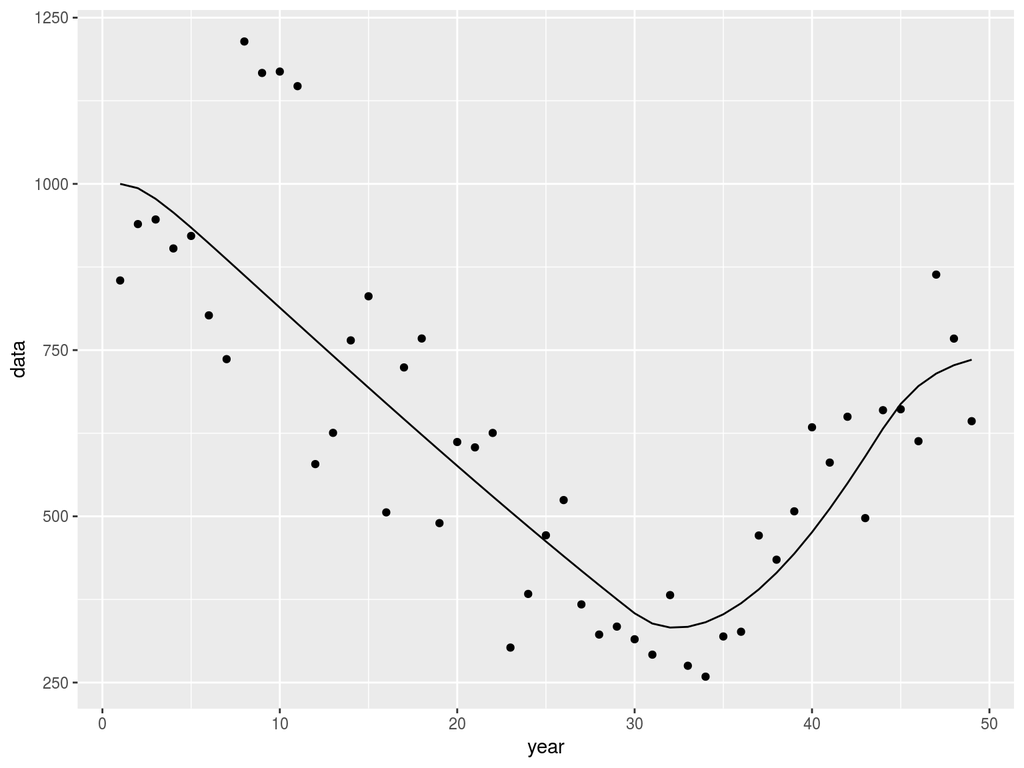

**Figure 3** Simulated indices of abundance.

## Assessment

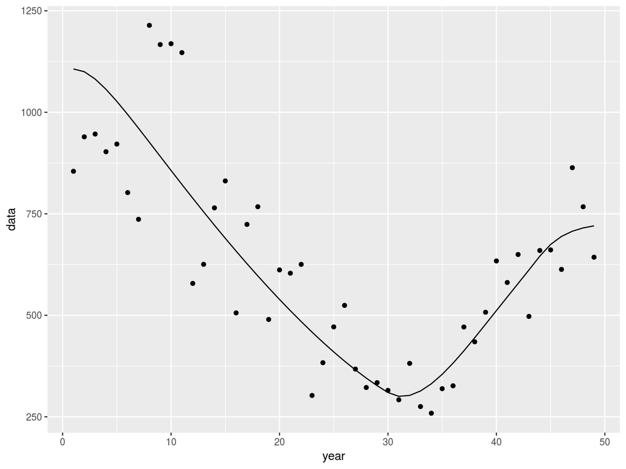

**Figure 4** Fitted CPUE

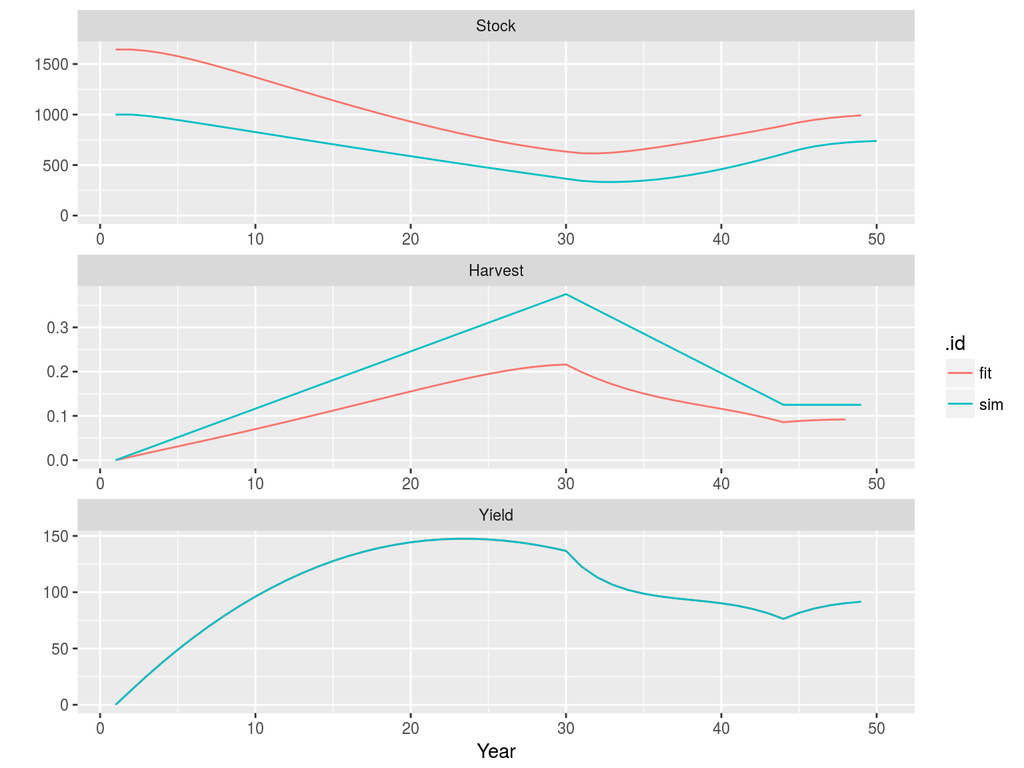

**Figure 5** Comparision of biomass dynamic estimates of stock, harvest rate and catch

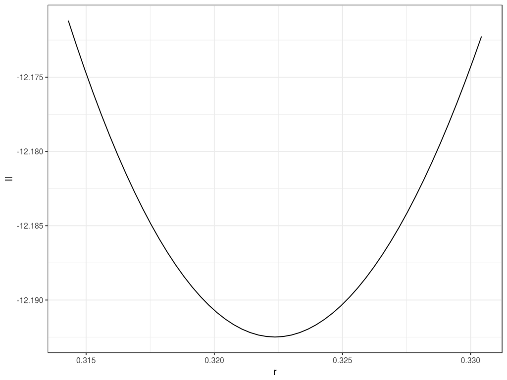

**Figure 6** Likelihood profile of r

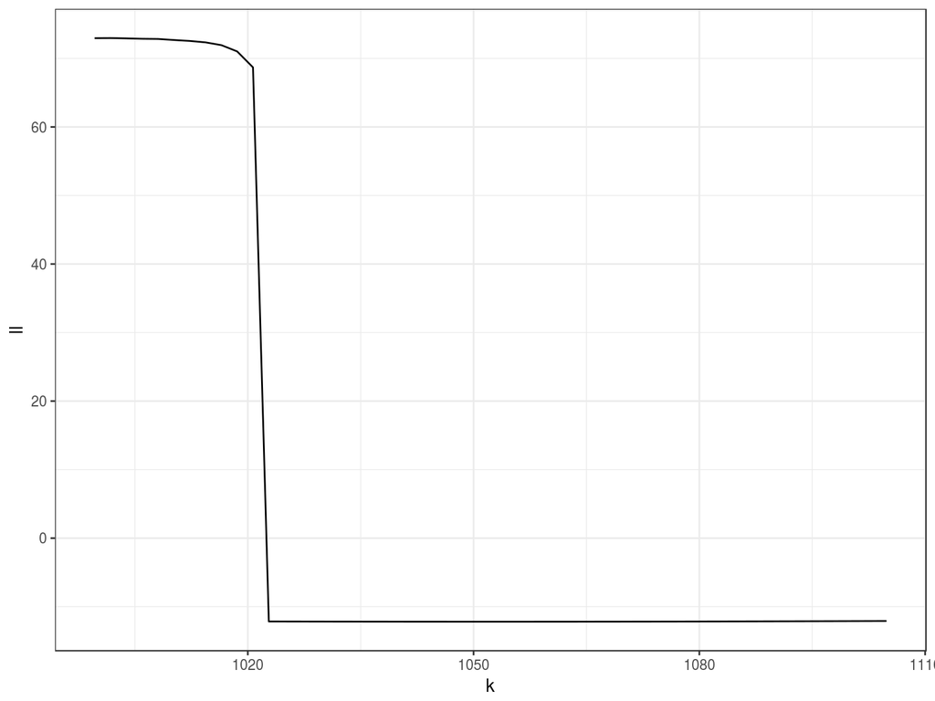

**Figure 7** Likelihood profile of K

/newpage Fit to the indices is evaluated by plotting the residuals. The first plot is of the observed and the predicted values. Since $U=qB$, i.e. the index is assumed to be proportional to stock size the points should fall either side of the $y=x$ line.

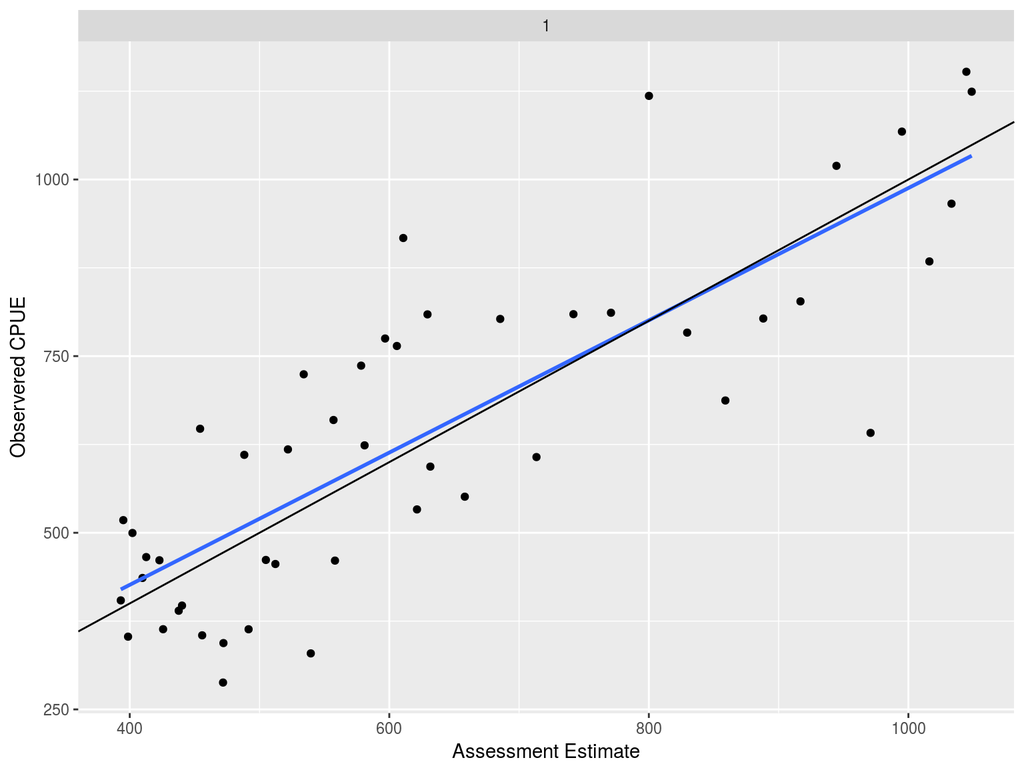

**Figure 8** Observed CPUE verses fitted, blue line is a linear resgression fitted to points, black the y=x line.

/newpage Departures from the assumption that the index is proportional to the stock can also be seen by plotting the residuals by time.

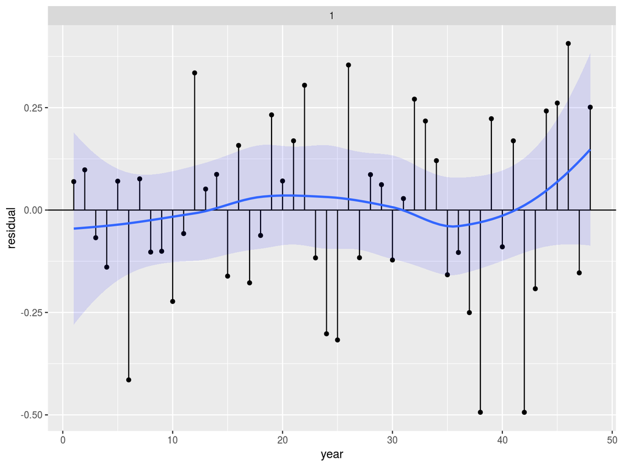

**Figure 9** Residuals by year, with lowess smoother and SEs.

/newpage Autocorrelated residuals may mean that the estimated parameters are biased, autocorrelation can be checked by plotting the residuals against each other with a lag e.g.

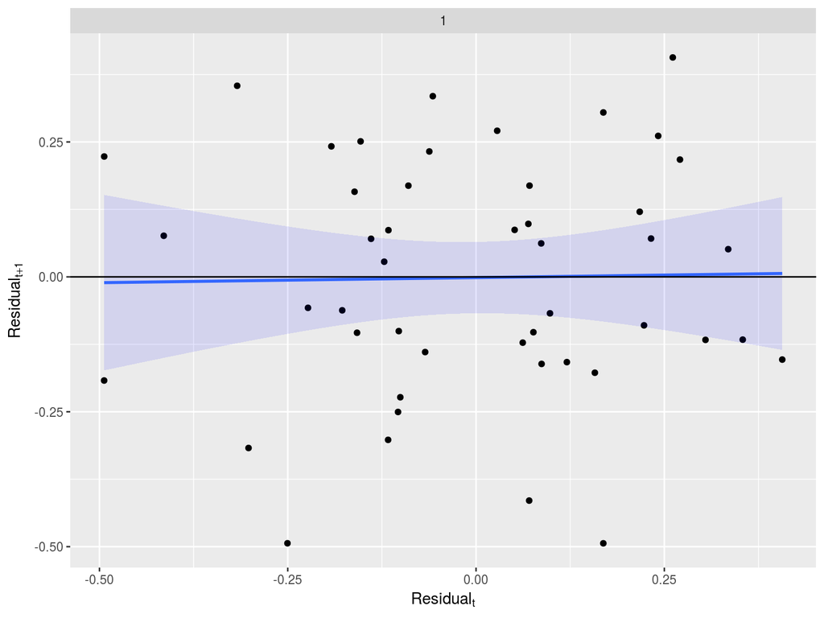

**Figure 10** Plot of autocorrelation, i.e. $residual_{t+1}$ verses $residual_{t}$.

/newpage The error dostribution can be checked by plotting the observed and the predicted quantiles for a given distribution e.g. for the normal distributuion

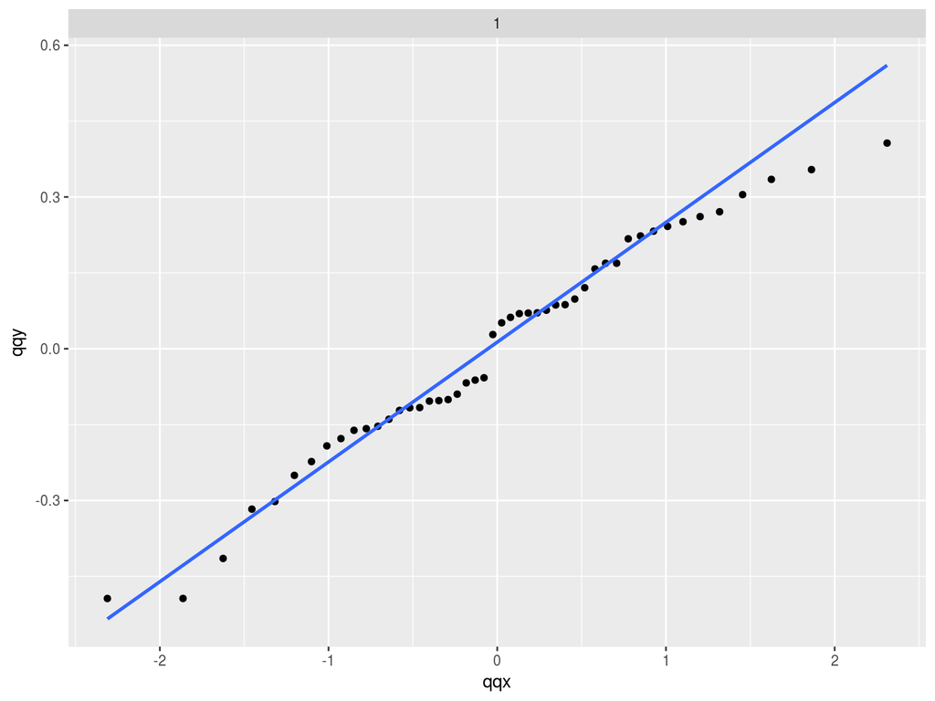

**Figure 11** Quantile-quantile plot to compare residual distribution with the normal distribution.

/newpage The variance

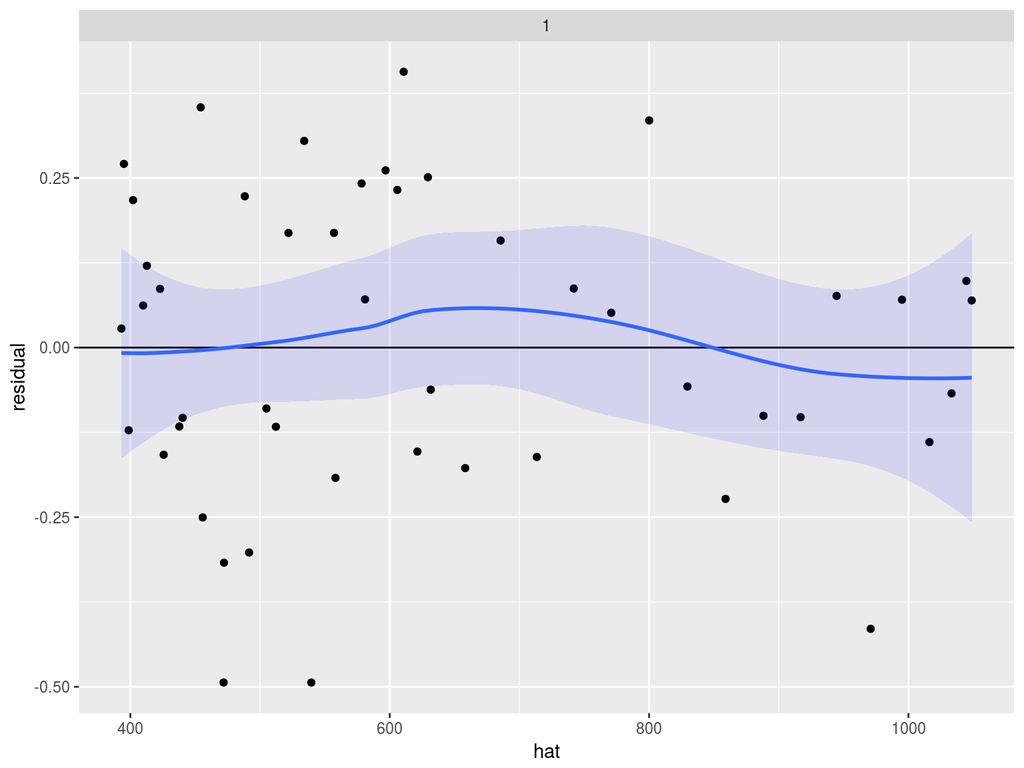

**Figure 12** Plot of residuals against fitted value, to check variance relationship.

## Profiles

Likelihood profiles are useful to check that you are actually at a global solution and not stuck on a small hill with your back to the mountain. They are also useful for evaluating the infomation content of the data and whether different data sets are telling you different things and you need to ask more questions to determine the truth.

The control slot can be used to produce a profile, i.e. fix a parameter or parameters for a range of values and then find the maximum likelihood by estimating the other parameters.

## Retrospective Analysis

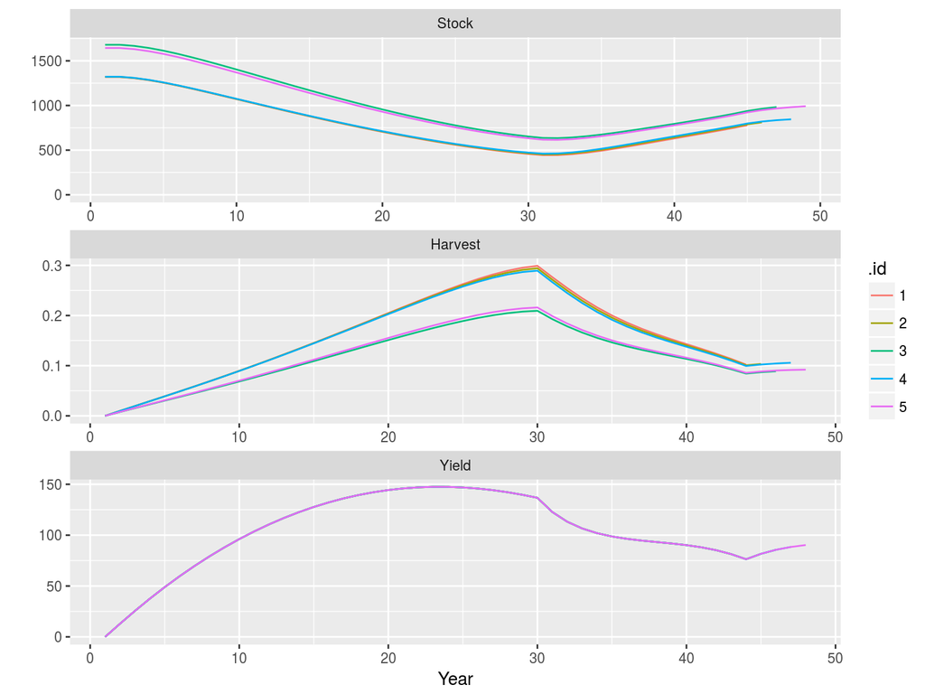

**Figure 13** Retrospective analysis.

## Projections

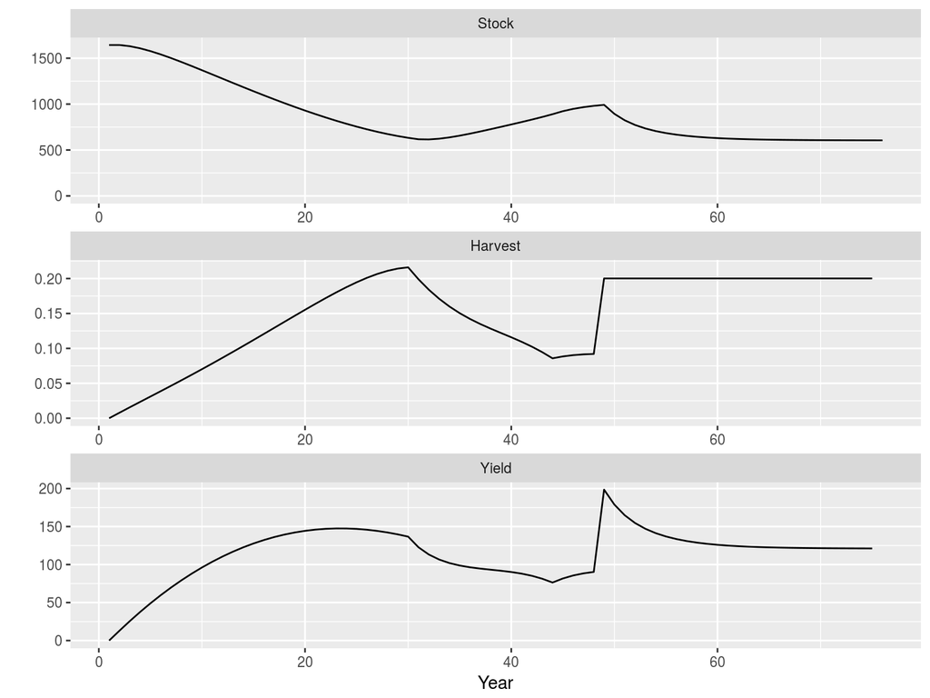

**Figure 15** Projection for Fmsy.

## Uncertainty

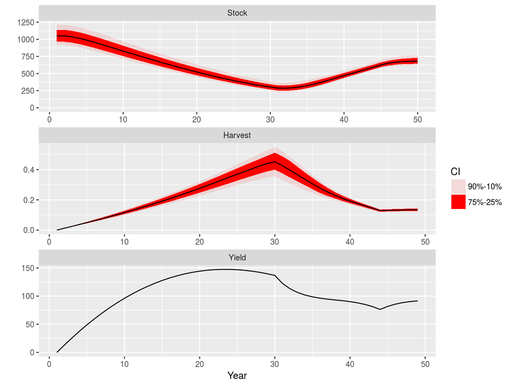

**Figure 16** Monte Carlo simulation.

## Software Versions

- R version 3.4.1 (2017-06-30)
- FLCore: 2.6.4.9003
- FLPKG:
- **Compiled**: Tue Mar 6 08:02:45 2018
- **Git Hash**: 6780aef

## Author information

**Laurence KELL**. laurie.kell.es

## Acknowledgements

This vignette and many of the methods documented in it were developed under the MyDas project funded by the Irish exchequer and EMFF 2014-2020. The overall aim of MyDas is to develop and test a range of assessment models and methods to establish Maximum Sustainable Yield (MSY) reference points (or proxy MSY reference points) across the spectrum of data-limited stocks.